# BikeshareDemand_AutoGluon_AG

## Project: Predict Bike Sharing Demand with AutoGluon

This notebook is a template with each step that you need to complete for the project.

Please fill in your code where there are explicit `?` markers in the notebook. You are welcome to add more cells and code as you see fit.

Once you have completed all the code implementations, please export your notebook as a HTML file so the reviews can view your code. Make sure you have all outputs correctly outputted.

`File-> Export Notebook As... -> Export Notebook as HTML`

There is a writeup to complete as well after all code implememtation is done. Please answer all questions and attach the necessary tables and charts. You can complete the writeup in either markdown or PDF.

Completing the code template and writeup template will cover all of the rubric points for this project.

The rubric contains "Stand Out Suggestions" for enhancing the project beyond the minimum requirements. The stand out suggestions are optional. If you decide to pursue the "stand out suggestions", you can include the code in this notebook and also discuss the results in the writeup file.

## Step 1: Create an account with Kaggle

### Create Kaggle Account and download API key

Below is example of steps to get the API username and key. Each student will have their own username and key.

1. Open account settings.

2. Scroll down to API and click Create New API Token.

3. Open up `kaggle.json` and use the username and key.


## Step 2: Download the Kaggle dataset using the kaggle python library

### Open up Sagemaker Studio and use starter template

1. Notebook should be using a `ml.t3.medium` instance (2 vCPU + 4 GiB)
2. Notebook should be using kernal: `Python 3 (MXNet 1.8 Python 3.7 CPU Optimized)`

### Install packages

```python
!pip install -U pip
!pip install -U setuptools wheel
!pip install -U "mxnet<2.0.0" bokeh==2.0.1
!pip install autogluon --no-cache-dir
# Without --no-cache-dir, smaller AWS instances may have trouble installing
```

[output not shown]

```python
# Import additional packages mainly used for EDA
import numpy as np
import seaborn as sns
import matplotlib.pyplot as plt
```

### Setup Kaggle API Key

```python
# create the .kaggle directory and an empty kaggle.json file
!pip install kaggle

!mkdir -p /root/.kaggle
!touch /root/.kaggle/kaggle.json
!chmod 600 /root/.kaggle/kaggle.json
```

```
WARNING: Running pip as the 'root' user can result in broken permissions and conflicting behaviour with the system package manager. It is recommended to use a virtual environment instead: https://pip.pypa.io/warnings/venv
```

```python
# Fill in your user name and key from creating the kaggle account and API token file
import json
kaggle_username = ""
kaggle_key = ""

# Save API token the kaggle.json file
with open("/root/.kaggle/kaggle.json", "w") as f:
    f.write(json.dumps({"username": kaggle_username, "key": kaggle_key}))
```

### Download and explore dataset

### Go to the [bike sharing demand competition](https://www.kaggle.com/c/bike-sharing-demand) and agree to the terms

```python
# Download the dataset, it will be in a .zip file so you'll need to unzip it as well.
!kaggle competitions download -c bike-sharing-demand
# If you already downloaded it you can use the -o command to overwrite the file
!unzip -o bike-sharing-demand.zip
```

```
bike-sharing-demand.zip: Skipping, found more recently modified local copy (use --force to force download)
Archive:  bike-sharing-demand.zip
  inflating: sampleSubmission.csv
  inflating: test.csv
  inflating: train.csv
```

```python
import pandas as pd
from autogluon.tabular import TabularPredictor
```

```python
# Create the train dataset in pandas by reading the csv
train = pd.read_csv('./bike-sharing-demand/train.csv', parse_dates=['datetime'])
train.head()
```

|  | datetime | season | holiday | workingday | weather | temp | atemp | humidity | windspeed | casual | registered | count |
| --- | --- | --- | --- | --- | --- | --- | --- | --- | --- | --- | --- | --- |
| 0 | 2011-01-01 00:00:00 | 1 | 0 | 0 | 1 | 9.84 | 14.395 | 81 | 0.0 | 3 | 13 | 16 |
| 1 | 2011-01-01 01:00:00 | 1 | 0 | 0 | 1 | 9.02 | 13.635 | 80 | 0.0 | 8 | 32 | 40 |
| 2 | 2011-01-01 02:00:00 | 1 | 0 | 0 | 1 | 9.02 | 13.635 | 80 | 0.0 | 5 | 27 | 32 |
| 3 | 2011-01-01 03:00:00 | 1 | 0 | 0 | 1 | 9.84 | 14.395 | 75 | 0.0 | 3 | 10 | 13 |
| 4 | 2011-01-01 04:00:00 | 1 | 0 | 0 | 1 | 9.84 | 14.395 | 75 | 0.0 | 0 | 1 | 1 |

```python
# Simple output of the train dataset to view some of the min/max/variation of the dataset features.
train.describe()
```

|  | season | holiday | workingday | weather | temp | atemp | humidity | windspeed | casual | registered | count |
| --- | --- | --- | --- | --- | --- | --- | --- | --- | --- | --- | --- |
| count | 10886.000000 | 10886.000000 | 10886.000000 | 10886.000000 | 10886.00000 | 10886.000000 | 10886.000000 | 10886.000000 | 10886.000000 | 10886.000000 | 10886.000000 |
| mean | 2.506614 | 0.028569 | 0.680875 | 1.418427 | 20.23086 | 23.655084 | 61.886460 | 12.799395 | 36.021955 | 155.552177 | 191.574132 |
| std | 1.116174 | 0.166599 | 0.466159 | 0.633839 | 7.79159 | 8.474601 | 19.245033 | 8.164537 | 49.960477 | 151.039033 | 181.144454 |
| min | 1.000000 | 0.000000 | 0.000000 | 1.000000 | 0.82000 | 0.760000 | 0.000000 | 0.000000 | 0.000000 | 0.000000 | 1.000000 |
| 25% | 2.000000 | 0.000000 | 0.000000 | 1.000000 | 13.94000 | 16.665000 | 47.000000 | 7.001500 | 4.000000 | 36.000000 | 42.000000 |
| 50% | 3.000000 | 0.000000 | 1.000000 | 1.000000 | 20.50000 | 24.240000 | 62.000000 | 12.998000 | 17.000000 | 118.000000 | 145.000000 |
| 75% | 4.000000 | 0.000000 | 1.000000 | 2.000000 | 26.24000 | 31.060000 | 77.000000 | 16.997900 | 49.000000 | 222.000000 | 284.000000 |
| max | 4.000000 | 1.000000 | 1.000000 | 4.000000 | 41.00000 | 45.455000 | 100.000000 | 56.996900 | 367.000000 | 886.000000 | 977.000000 |

```python
# Create the test pandas dataframe in pandas by reading the csv, remember to parse the datetime!
test = pd.read_csv('./bike-sharing-demand/test.csv', parse_dates=['datetime'])
test.head()
```

|  | datetime | season | holiday | workingday | weather | temp | atemp | humidity | windspeed |
| --- | --- | --- | --- | --- | --- | --- | --- | --- | --- |
| 0 | 2011-01-20 00:00:00 | 1 | 0 | 1 | 1 | 10.66 | 11.365 | 56 | 26.0027 |
| 1 | 2011-01-20 01:00:00 | 1 | 0 | 1 | 1 | 10.66 | 13.635 | 56 | 0.0000 |
| 2 | 2011-01-20 02:00:00 | 1 | 0 | 1 | 1 | 10.66 | 13.635 | 56 | 0.0000 |
| 3 | 2011-01-20 03:00:00 | 1 | 0 | 1 | 1 | 10.66 | 12.880 | 56 | 11.0014 |
| 4 | 2011-01-20 04:00:00 | 1 | 0 | 1 | 1 | 10.66 | 12.880 | 56 | 11.0014 |

```python
# Same thing as train and test dataset - to be changed to 'submission'
submission = pd.read_csv('./bike-sharing-demand/sampleSubmission.csv', parse_dates=['datetime'])
submission.head()
```

|  | datetime | count |
| --- | --- | --- |
| 0 | 2011-01-20 00:00:00 | 0 |
| 1 | 2011-01-20 01:00:00 | 0 |
| 2 | 2011-01-20 02:00:00 | 0 |
| 3 | 2011-01-20 03:00:00 | 0 |
| 4 | 2011-01-20 04:00:00 | 0 |

## Step 3: Train a model using AutoGluon’s Tabular Prediction

Requirements:

- We are predicting `count`, so it is the label we are setting.
- Ignore `casual` and `registered` columns as they are also not present in the test dataset.
- Use the `root_mean_squared_error` as the metric to use for evaluation.
- Set a time limit of 10 minutes (600 seconds).
- Use the preset `best_quality` to focus on creating the best model.

```python
# Testing - check whether regression is best option
predictor = TabularPredictor(
    label = 'count',problem_type='regression',eval_metric = 'rmse').fit(
        train_data=train.drop(['casual','registered'], axis=1),
        time_limit=600,
        presets='best_quality'
)
```

```
No path specified. Models will be saved in: "AutogluonModels/ag-20230218_204003/"
Presets specified: ['best_quality']
Stack configuration (auto_stack=True): num_stack_levels=1, num_bag_folds=8, num_bag_sets=20
Beginning AutoGluon training ... Time limit = 600s
AutoGluon will save models to "AutogluonModels/ag-20230218_204003/"
AutoGluon Version:  0.6.2
Python Version:     3.7.10
Operating System:   Linux
Platform Machine:   x86_64
Platform Version:   #1 SMP Fri Dec 9 09:57:03 UTC 2022
Train Data Rows:    10886
Train Data Columns: 9
Label Column: count
Preprocessing data ...
Using Feature Generators to preprocess the data ...
Fitting AutoMLPipelineFeatureGenerator...
	Available Memory:                    2960.15 MB
	Train Data (Original)  Memory Usage: 0.78 MB (0.0% of available memory)
	Inferring data type of each feature based on column values. Set feature_metadata_in to manually specify special dtypes of the features.
	Stage 1 Generators:
		Fitting AsTypeFeatureGenerator...
			Note: Converting 2 features to boolean dtype as they only contain 2 unique values.
	Stage 2 Generators:
		Fitting FillNaFeatureGenerator...
	Stage 3 Generators:
		Fitting IdentityFeatureGenerator...
		Fitting DatetimeFeatureGenerator...
	Stage 4 Generators:
		Fitting DropUniqueFeatureGenerator...
	Types of features in original data (raw dtype, special dtypes):
		('datetime', []) : 1 | ['datetime']
		('float', [])    : 3 | ['temp', 'atemp', 'windspeed']
		('int', [])      : 5 | ['season', 'holiday', 'workingday', 'weather', 'humidity']
	Types of features in processed data (raw dtype, special dtypes):
		('float', [])                : 3 | ['temp', 'atemp', 'windspeed']
		('int', [])                  : 3 | ['season', 'weather', 'humidity']
		('int', ['bool'])            : 2 | ['holiday', 'workingday']
		('int', ['datetime_as_int']) : 5 | ['datetime', 'datetime.year', 'datetime.month', 'datetime.day', 'datetime.dayofweek']
	0.7s = Fit runtime
	9 features in original data used to generate 13 features in processed data.
```

[output cut: 60 more lines]

```
	-53.4065	 = Validation score   (-root_mean_squared_error)
	26.41s	 = Training   runtime
	0.6s	 = Validation runtime
Fitting model: CatBoost_BAG_L2 ... Training model for up to 64.55s of the 64.53s of remaining time.
	Fitting 8 child models (S1F1 - S1F8) | Fitting with ParallelLocalFoldFittingStrategy
	-55.5292	 = Validation score   (-root_mean_squared_error)
	62.2s	 = Training   runtime
	0.05s	 = Validation runtime
Completed 1/20 k-fold bagging repeats ...
Fitting model: WeightedEnsemble_L3 ... Training model for up to 360.0s of the -1.68s of remaining time.
	-53.0998	 = Validation score   (-root_mean_squared_error)
	0.28s	 = Training   runtime
	0.0s	 = Validation runtime
AutoGluon training complete, total runtime = 602.16s ... Best model: "WeightedEnsemble_L3"
TabularPredictor saved. To load, use: predictor = TabularPredictor.load("AutogluonModels/ag-20230218_204003/")
```

### Review AutoGluon's training run with ranking of models that did the best.

```python
predictor.fit_summary()
```

```
*** Summary of fit() ***
Estimated performance of each model:
                     model   score_val  pred_time_val    fit_time  pred_time_val_marginal  fit_time_marginal  stack_level  can_infer  fit_order
0      WeightedEnsemble_L3  -53.099805      15.051839  549.630720                0.000920           0.283833            3       True         14
1   RandomForestMSE_BAG_L2  -53.406487      11.043491  411.371704                0.601129          26.406358            2       True         12
2          LightGBM_BAG_L2  -55.213531      10.650581  408.159001                0.208219          23.193655            2       True         11
3          CatBoost_BAG_L2  -55.529195      10.496111  447.163736                0.053749          62.198390            2       True         13
4        LightGBMXT_BAG_L2  -60.300912      14.187822  437.548484                3.745460          52.583138            2       True         10
5    KNeighborsDist_BAG_L1  -84.125061       0.103793    0.029674                0.103793           0.029674            1       True          2
6      WeightedEnsemble_L2  -84.125061       0.106616    0.884734                0.002823           0.855060            2       True          9
7    KNeighborsUnif_BAG_L1 -101.546199       0.108684    0.034644                0.108684           0.034644            1       True          1
8   RandomForestMSE_BAG_L1 -116.544294       0.536408   11.306235                0.536408          11.306235            1       True          5
9     ExtraTreesMSE_BAG_L1 -124.588053       0.536402    4.945369                0.536402           4.945369            1       True          7
10         CatBoost_BAG_L1 -130.534987       0.086561  201.525412                0.086561         201.525412            1       True          6
11         LightGBM_BAG_L1 -131.054162       1.496559   28.827601                1.496559          28.827601            1       True          4
12       LightGBMXT_BAG_L1 -131.460909       6.898653   64.003081                6.898653          64.003081            1       True          3
13  NeuralNetFastAI_BAG_L1 -137.804317       0.675302   74.293329                0.675302          74.293329            1       True          8
Number of models trained: 14
Types of models trained:
{'StackerEnsembleModel_XT', 'StackerEnsembleModel_NNFastAiTabular', 'StackerEnsembleModel_CatBoost', 'StackerEnsembleModel_KNN', 'StackerEnsembleModel_RF', 'StackerEnsembleModel_LGB', 'WeightedEnsembleModel'}
Bagging used: True  (with 8 folds)
Multi-layer stack-ensembling used: True  (with 3 levels)
Feature Metadata (Processed):
(raw dtype, special dtypes):
('float', [])                : 3 | ['temp', 'atemp', 'windspeed']
('int', [])                  : 3 | ['season', 'weather', 'humidity']
('int', ['bool'])            : 2 | ['holiday', 'workingday']
('int', ['datetime_as_int']) : 5 | ['datetime', 'datetime.year', 'datetime.month', 'datetime.day', 'datetime.dayofweek']
Plot summary of models saved to file: AutogluonModels/ag-20230218_204003/SummaryOfModels.html
*** End of fit() summary ***
```

```
{'model_types': {'KNeighborsUnif_BAG_L1': 'StackerEnsembleModel_KNN',
  'KNeighborsDist_BAG_L1': 'StackerEnsembleModel_KNN',
  'LightGBMXT_BAG_L1': 'StackerEnsembleModel_LGB',
  'LightGBM_BAG_L1': 'StackerEnsembleModel_LGB',
  'RandomForestMSE_BAG_L1': 'StackerEnsembleModel_RF',
  'CatBoost_BAG_L1': 'StackerEnsembleModel_CatBoost',
  'ExtraTreesMSE_BAG_L1': 'StackerEnsembleModel_XT',
  'NeuralNetFastAI_BAG_L1': 'StackerEnsembleModel_NNFastAiTabular',
  'WeightedEnsemble_L2': 'WeightedEnsembleModel',
  'LightGBMXT_BAG_L2': 'StackerEnsembleModel_LGB',
  'LightGBM_BAG_L2': 'StackerEnsembleModel_LGB',
  'RandomForestMSE_BAG_L2': 'StackerEnsembleModel_RF',
  'CatBoost_BAG_L2': 'StackerEnsembleModel_CatBoost',
  'WeightedEnsemble_L3': 'WeightedEnsembleModel'},
 'model_performance': {'KNeighborsUnif_BAG_L1': -101.54619908446061,
  'KNeighborsDist_BAG_L1': -84.12506123181602,
  'LightGBMXT_BAG_L1': -131.46090891834504,
  'LightGBM_BAG_L1': -131.054161598899,
  'RandomForestMSE_BAG_L1': -116.54429428704391,
  'CatBoost_BAG_L1': -130.53498689275415,
  'ExtraTreesMSE_BAG_L1': -124.58805258915959,
  'NeuralNetFastAI_BAG_L1': -137.8043174577873,
  'WeightedEnsemble_L2': -84.12506123181602,
  'LightGBMXT_BAG_L2': -60.30091175188206,
  'LightGBM_BAG_L2': -55.213531208395565,
  'RandomForestMSE_BAG_L2': -53.40648730486286,
  'CatBoost_BAG_L2': -55.52919536026125,
  'WeightedEnsemble_L3': -53.099804718188494},
 'model_best': 'WeightedEnsemble_L3',
 'model_paths': {'KNeighborsUnif_BAG_L1': 'AutogluonModels/ag-20230218_204003/models/KNeighborsUnif_BAG_L1/',
  'KNeighborsDist_BAG_L1': 'AutogluonModels/ag-20230218_204003/models/KNeighborsDist_BAG_L1/',
  'LightGBMXT_BAG_L1': 'AutogluonModels/ag-20230218_204003/models/LightGBMXT_BAG_L1/',
  'LightGBM_BAG_L1': 'AutogluonModels/ag-20230218_204003/models/LightGBM_BAG_L1/',
  'RandomForestMSE_BAG_L1': 'AutogluonModels/ag-20230218_204003/models/RandomForestMSE_BAG_L1/',
  'CatBoost_BAG_L1': 'AutogluonModels/ag-20230218_204003/models/CatBoost_BAG_L1/',
  'ExtraTreesMSE_BAG_L1': 'AutogluonModels/ag-20230218_204003/models/ExtraTreesMSE_BAG_L1/',
  'NeuralNetFastAI_BAG_L1': 'AutogluonModels/ag-20230218_204003/models/NeuralNetFastAI_BAG_L1/',
  'WeightedEnsemble_L2': 'AutogluonModels/ag-20230218_204003/models/WeightedEnsemble_L2/',
  'LightGBMXT_BAG_L2': 'AutogluonModels/ag-20230218_204003/models/LightGBMXT_BAG_L2/',
  'LightGBM_BAG_L2': 'AutogluonModels/ag-20230218_204003/models/LightGBM_BAG_L2/',
```

[output cut: 126 more lines]

```
     fit_order
 0          14
 1          12
 2          11
 3          13
 4          10
 5           2
 6           9
 7           1
 8           5
 9           7
 10          6
 11          4
 12          3
 13          8  }
```

### Create predictions from test dataset

```python
# Predict on test set and turn results into df: need to add predictions as new column
predictions = predictor.predict(test)
predictions = pd.DataFrame(data={'datetime': test['datetime'], 'pred_count': predictions})
predictions.head()
```

|  | datetime | pred_count |
| --- | --- | --- |
| 0 | 2011-01-20 00:00:00 | 23.908726 |
| 1 | 2011-01-20 01:00:00 | 42.995575 |
| 2 | 2011-01-20 02:00:00 | 45.966187 |
| 3 | 2011-01-20 03:00:00 | 50.242737 |
| 4 | 2011-01-20 04:00:00 | 52.686298 |

#### NOTE: Kaggle will reject the submission if we don't set everything to be > 0.

```python
# Describe the `predictions` series to see if there are any negative values
predictions.describe()
```

|  | pred_count |
| --- | --- |
| count | 6493.000000 |
| mean | 101.000397 |
| std | 90.176956 |
| min | 3.125437 |
| 25% | 20.197660 |
| 50% | 64.385498 |
| 75% | 167.243759 |
| max | 363.399536 |

```python
# How many negative values do we have?
neg_counts = predictions[['pred_count']].agg(lambda x: sum(x < 0)).sum()
print(neg_counts)
```

```
0
```

```python
# Set them to zero
predictions[predictions['pred_count'] < 0] = 0
```

### Set predictions to submission dataframe, save, and submit

```python
submission['count'] = predictions['pred_count']
submission.to_csv('./bike-sharing-demand/submission.csv', index=False)
```

```python
!kaggle competitions submit -c bike-sharing-demand -f ./bike-sharing-demand/submission.csv -m "first raw submission"
```

```
Successfully submitted to Bike Sharing Demand
```

#### View submission via the command line or in the web browser under the competition's page - `My Submissions`

```python
!kaggle competitions submissions -c bike-sharing-demand | tail -n +1 | head -n 6
```

```
fileName                      date                 description                                                                                                                                                                                                                   status    publicScore  priv…
----------------------------  -------------------  ----------------------------------------------------------------------------------------------------------------------------------------------------------------------------------------------------------------------------  --------  -----------  ----…
submission.csv                2023-02-18 20:50:42  first raw submission                                                                                                                                                                                                          complete  1.79163      1.79…
submission.csv                2023-02-18 20:36:40  first raw submission                                                                                                                                                                                                          complete  1.80912      1.80…
submission.csv                2023-02-18 20:30:04  first raw submission                                                                                                                                                                                                          complete  1.80912      1.80…
submission_new_hpo.csv        2023-02-17 20:58:36  Sbumission with new features added as in "new_features1" plus some hyper-parameter tuning as part of AutoGluon ML: new_features_hpo                                                                                           complete  0.49051      0.49…
```

#### Initial score of `1.79163`

## Step 4: Exploratory Data Analysis and Creating an additional feature

- Any additional feature will do, but a great suggestion would be to separate out the datetime into hour, day, or month parts.

[figure not shown]

```python
# Create a histogram of all features to show the distribution of each one relative to the data. This is part of the exploritory data analysi
train.hist(figsize=(20,20));
```

```python
# Calculate correlations amongst numerical features
numeric = ['int8','int16','int32','int64','float16','float32','float64']
num_cols = list(train.select_dtypes(include=numeric).columns)
train_corr = train[num_cols].corr()
```

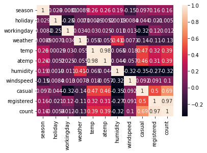

```python
# Plot a simple heatmap of correlation
corr_heatmap = sns.heatmap(train_corr, annot=True)
plt.show()
```

```python
# create a new feature - year, month, day, hour and weekday added initially
train['year'] = train['datetime'].dt.year
train['month'] = train['datetime'].dt.month
train['day'] = train['datetime'].dt.day
train['weekday'] = train['datetime'].dt.weekday
train['hour'] = train['datetime'].dt.hour

test['year'] = test['datetime'].dt.year
test['month'] = test['datetime'].dt.month
test['day'] = test['datetime'].dt.day
test['weekday'] = test['datetime'].dt.weekday
test['hour'] = test['datetime'].dt.hour
```

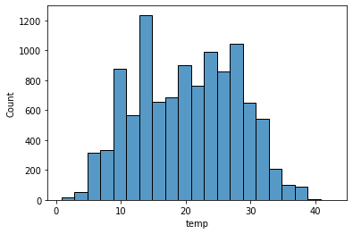

```python
# Generate histogram of temp ahead of creating a new binned version of the variable
sns.histplot(data=train, x='temp', binwidth=2)
#sns.histplot(data=train, x='temp', bins=20)
```

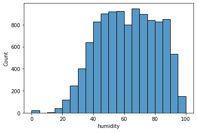

```python
# Generate histogram of humidity ahead of creating a new binned version of the variable
sns.histplot(data=train, x='humidity', binwidth=5)
```

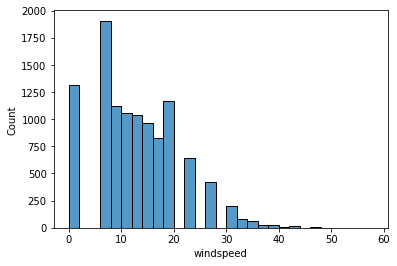

```python
# Generate histogram of windspeed ahead of creating a new binned version of the variable
sns.histplot(data=train, x='windspeed', binwidth=2)
```

```python
# Create new features - bin temp, humidity and wind speeds
train['temp_level'] = pd.cut(train['temp'], bins=[-1,10,30,np.inf], labels=['cold', 'warm', 'hot'])
train['humidity_level'] = pd.cut(train['humidity'], bins=[-1,20,40,85,101], labels=['very_dry', 'dry', 'humid', 'very_humid'])
train['windspeed_level'] =  pd.cut(train['windspeed'], bins=[-1,10,20,30,np.inf], labels=['calm', 'light_wind', 'windy', 'very_windy'])
```

```python
# Now also add the binned features to test data
test['temp_level'] = pd.cut(test['temp'], bins=[-1,10,30,np.inf], labels=['cold', 'warm', 'hot'])
test['humidity_level'] = pd.cut(test['humidity'], bins=[-1,20,40,85,101], labels=['very_dry', 'dry', 'humid', 'very_humid'])
test['windspeed_level'] =  pd.cut(test['windspeed'], bins=[-1,10,20,30,np.inf], labels=['calm', 'light_wind', 'windy', 'very_windy'])
```

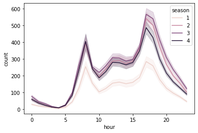

```python
# Generate a quick plot of the counts by hour
sns.lineplot(data=train, x='hour', y='count', hue='season')
```

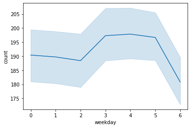

```python
# Plot counts against weekday
sns.lineplot(data=train, x='weekday', y='count')
```

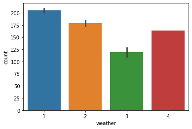

```python
# Plot counts by weather
sns.barplot(data=train, x='weather', y='count')
```

## Make category types for these so models know they are not just numbers

- AutoGluon originally sees these as ints, but in reality they are int representations of a category.
- Setting the dtype to category will classify these as categories in AutoGluon.

```python
train["season"] = train["season"].astype("category")
train["weather"] = train["weather"].astype("category")
test["season"] = test["season"].astype("category")
test["weather"] = test["weather"].astype("category")
```

```python
# View are new feature
train.head()
```

|  | datetime | season | holiday | workingday | weather | temp | atemp | humidity | windspeed | casual | registered | count | year | month | day | weekday | hour | temp_level | humidity_level | windspeed_level |
| --- | --- | --- | --- | --- | --- | --- | --- | --- | --- | --- | --- | --- | --- | --- | --- | --- | --- | --- | --- | --- |
| 0 | 2011-01-01 00:00:00 | 1 | 0 | 0 | 1 | 9.84 | 14.395 | 81 | 0.0 | 3 | 13 | 16 | 2011 | 1 | 1 | 5 | 0 | cold | humid | calm |
| 1 | 2011-01-01 01:00:00 | 1 | 0 | 0 | 1 | 9.02 | 13.635 | 80 | 0.0 | 8 | 32 | 40 | 2011 | 1 | 1 | 5 | 1 | cold | humid | calm |
| 2 | 2011-01-01 02:00:00 | 1 | 0 | 0 | 1 | 9.02 | 13.635 | 80 | 0.0 | 5 | 27 | 32 | 2011 | 1 | 1 | 5 | 2 | cold | humid | calm |
| 3 | 2011-01-01 03:00:00 | 1 | 0 | 0 | 1 | 9.84 | 14.395 | 75 | 0.0 | 3 | 10 | 13 | 2011 | 1 | 1 | 5 | 3 | cold | humid | calm |
| 4 | 2011-01-01 04:00:00 | 1 | 0 | 0 | 1 | 9.84 | 14.395 | 75 | 0.0 | 0 | 1 | 1 | 2011 | 1 | 1 | 5 | 4 | cold | humid | calm |

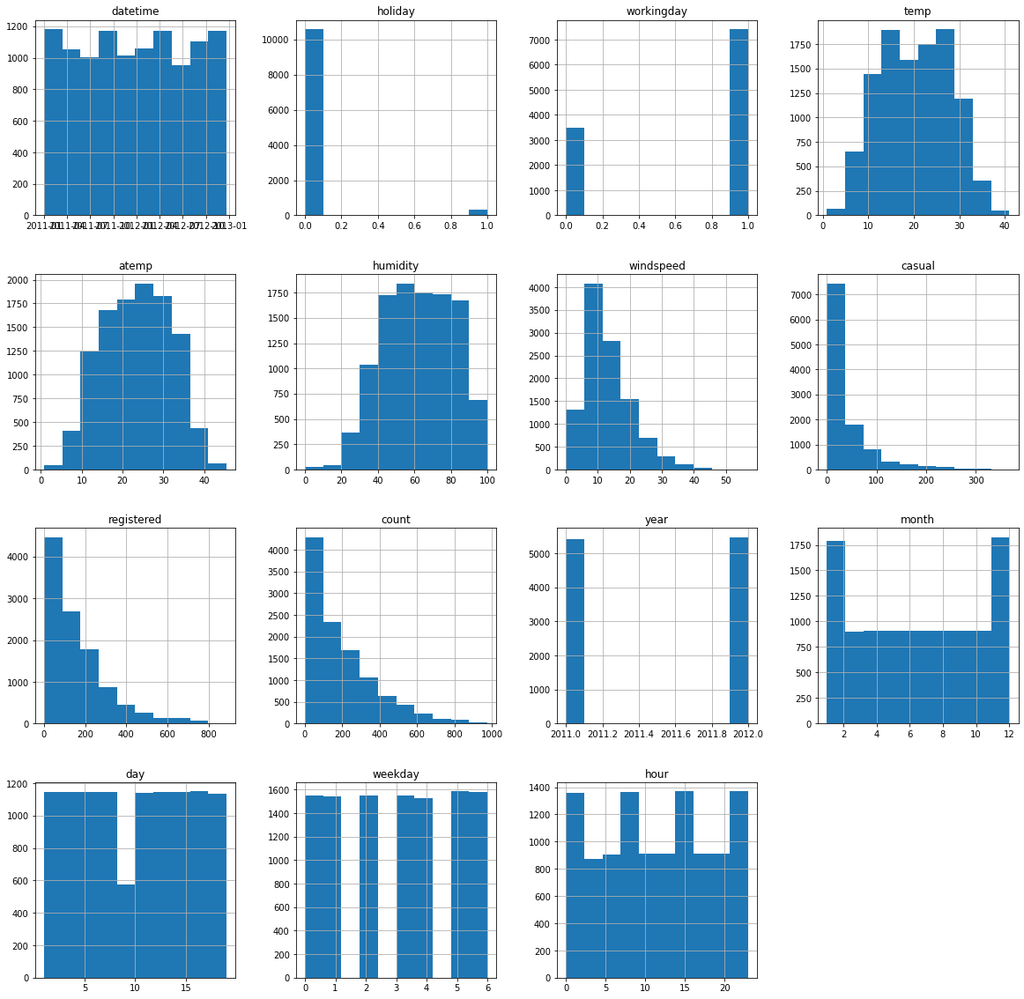

```python
# View histogram of all features again now with the hour feature
train.hist(figsize=(20,20));
```

## Step 5: Rerun the model with the same settings as before, just with more features

```python
# First submission with year, month, day, hour, weekday added as new features. Binned variables were not used but
# the original weather variables were retained. Also removed were 'holiday','workingday' with no correlation with the
# target variable, and 'atemp' which is highly correlated with variable 'temp'.
predictor_new_features1 = TabularPredictor(
    label = 'count',problem_type='regression',eval_metric = 'rmse',
    ).fit(
        train_data=train.drop(['casual','registered','holiday','workingday','atemp','temp_level','humidity_level','windspeed_level'], axis=1),
        time_limit=600,
        presets='best_quality'
)
```

```
No path specified. Models will be saved in: "AutogluonModels/ag-20230218_205053/"
Presets specified: ['best_quality']
Stack configuration (auto_stack=True): num_stack_levels=1, num_bag_folds=8, num_bag_sets=20
Beginning AutoGluon training ... Time limit = 600s
AutoGluon will save models to "AutogluonModels/ag-20230218_205053/"
AutoGluon Version:  0.6.2
Python Version:     3.7.10
Operating System:   Linux
Platform Machine:   x86_64
Platform Version:   #1 SMP Fri Dec 9 09:57:03 UTC 2022
Train Data Rows:    10886
Train Data Columns: 11
Label Column: count
Preprocessing data ...
Using Feature Generators to preprocess the data ...
Fitting AutoMLPipelineFeatureGenerator...
	Available Memory:                    2152.91 MB
	Train Data (Original)  Memory Usage: 0.81 MB (0.0% of available memory)
	Inferring data type of each feature based on column values. Set feature_metadata_in to manually specify special dtypes of the features.
	Stage 1 Generators:
		Fitting AsTypeFeatureGenerator...
			Note: Converting 1 features to boolean dtype as they only contain 2 unique values.
	Stage 2 Generators:
		Fitting FillNaFeatureGenerator...
	Stage 3 Generators:
		Fitting IdentityFeatureGenerator...
		Fitting CategoryFeatureGenerator...
			Fitting CategoryMemoryMinimizeFeatureGenerator...
		Fitting DatetimeFeatureGenerator...
	Stage 4 Generators:
		Fitting DropUniqueFeatureGenerator...
	Types of features in original data (raw dtype, special dtypes):
		('category', []) : 2 | ['season', 'weather']
		('datetime', []) : 1 | ['datetime']
		('float', [])    : 2 | ['temp', 'windspeed']
		('int', [])      : 6 | ['humidity', 'year', 'month', 'day', 'weekday', ...]
	Types of features in processed data (raw dtype, special dtypes):
		('category', [])             : 2 | ['season', 'weather']
		('float', [])                : 2 | ['temp', 'windspeed']
		('int', [])                  : 5 | ['humidity', 'month', 'day', 'weekday', 'hour']
```

[output cut: 64 more lines]

```
	-33.5198	 = Validation score   (-root_mean_squared_error)
	30.12s	 = Training   runtime
	0.61s	 = Validation runtime
Fitting model: CatBoost_BAG_L2 ... Training model for up to 58.15s of the 58.12s of remaining time.
	Fitting 8 child models (S1F1 - S1F8) | Fitting with ParallelLocalFoldFittingStrategy
	-32.0908	 = Validation score   (-root_mean_squared_error)
	58.44s	 = Training   runtime
	0.1s	 = Validation runtime
Completed 1/20 k-fold bagging repeats ...
Fitting model: WeightedEnsemble_L3 ... Training model for up to 360.0s of the -4.09s of remaining time.
	-31.49	 = Validation score   (-root_mean_squared_error)
	0.29s	 = Training   runtime
	0.0s	 = Validation runtime
AutoGluon training complete, total runtime = 604.58s ... Best model: "WeightedEnsemble_L3"
TabularPredictor saved. To load, use: predictor = TabularPredictor.load("AutogluonModels/ag-20230218_205053/")
```

```python
predictor_new_features1.fit_summary()
```

```
*** Summary of fit() ***
Estimated performance of each model:
                     model   score_val  pred_time_val    fit_time  pred_time_val_marginal  fit_time_marginal  stack_level  can_infer  fit_order
0      WeightedEnsemble_L3  -31.490033      34.538589  529.574717                0.001307           0.293043            3       True         14
1          LightGBM_BAG_L2  -31.946272      32.084173  426.513722                0.703508          29.886655            2       True         11
2          CatBoost_BAG_L2  -32.090799      31.479746  455.067452                0.099081          58.440385            2       True         13
3        LightGBMXT_BAG_L2  -32.618216      33.734693  440.954634                2.354028          44.327567            2       True         10
4   RandomForestMSE_BAG_L2  -33.519836      31.988191  426.751381                0.607526          30.124314            2       True         12
5      WeightedEnsemble_L2  -35.191504      30.239048  358.648250                0.000928           0.510760            2       True          9
6          LightGBM_BAG_L1  -36.958295       6.769329   65.242949                6.769329          65.242949            1       True          4
7          CatBoost_BAG_L1  -37.729049       0.166426  169.058087                0.166426         169.058087            1       True          6
8        LightGBMXT_BAG_L1  -37.901159      22.639051  109.692286               22.639051         109.692286            1       True          3
9   RandomForestMSE_BAG_L1  -41.452140       0.559739   14.110953                0.559739          14.110953            1       True          5
10    ExtraTreesMSE_BAG_L1  -41.523975       0.561319    5.967756                0.561319           5.967756            1       True          7
11   KNeighborsDist_BAG_L1  -84.125061       0.103575    0.033215                0.103575           0.033215            1       True          2
12   KNeighborsUnif_BAG_L1 -101.546199       0.103159    0.032928                0.103159           0.032928            1       True          1
13  NeuralNetFastAI_BAG_L1 -126.652685       0.478067   32.488894                0.478067          32.488894            1       True          8
Number of models trained: 14
Types of models trained:
{'StackerEnsembleModel_XT', 'StackerEnsembleModel_NNFastAiTabular', 'StackerEnsembleModel_CatBoost', 'StackerEnsembleModel_KNN', 'StackerEnsembleModel_RF', 'StackerEnsembleModel_LGB', 'WeightedEnsembleModel'}
Bagging used: True  (with 8 folds)
Multi-layer stack-ensembling used: True  (with 3 levels)
Feature Metadata (Processed):
(raw dtype, special dtypes):
('category', [])             : 2 | ['season', 'weather']
('float', [])                : 2 | ['temp', 'windspeed']
('int', [])                  : 5 | ['humidity', 'month', 'day', 'weekday', 'hour']
('int', ['bool'])            : 1 | ['year']
('int', ['datetime_as_int']) : 5 | ['datetime', 'datetime.year', 'datetime.month', 'datetime.day', 'datetime.dayofweek']
Plot summary of models saved to file: AutogluonModels/ag-20230218_205053/SummaryOfModels.html
*** End of fit() summary ***
```

```
{'model_types': {'KNeighborsUnif_BAG_L1': 'StackerEnsembleModel_KNN',
  'KNeighborsDist_BAG_L1': 'StackerEnsembleModel_KNN',
  'LightGBMXT_BAG_L1': 'StackerEnsembleModel_LGB',
  'LightGBM_BAG_L1': 'StackerEnsembleModel_LGB',
  'RandomForestMSE_BAG_L1': 'StackerEnsembleModel_RF',
  'CatBoost_BAG_L1': 'StackerEnsembleModel_CatBoost',
  'ExtraTreesMSE_BAG_L1': 'StackerEnsembleModel_XT',
  'NeuralNetFastAI_BAG_L1': 'StackerEnsembleModel_NNFastAiTabular',
  'WeightedEnsemble_L2': 'WeightedEnsembleModel',
  'LightGBMXT_BAG_L2': 'StackerEnsembleModel_LGB',
  'LightGBM_BAG_L2': 'StackerEnsembleModel_LGB',
  'RandomForestMSE_BAG_L2': 'StackerEnsembleModel_RF',
  'CatBoost_BAG_L2': 'StackerEnsembleModel_CatBoost',
  'WeightedEnsemble_L3': 'WeightedEnsembleModel'},
 'model_performance': {'KNeighborsUnif_BAG_L1': -101.54619908446061,
  'KNeighborsDist_BAG_L1': -84.12506123181602,
  'LightGBMXT_BAG_L1': -37.901158847126844,
  'LightGBM_BAG_L1': -36.95829523167032,
  'RandomForestMSE_BAG_L1': -41.45214041922571,
  'CatBoost_BAG_L1': -37.72904919228458,
  'ExtraTreesMSE_BAG_L1': -41.52397542417256,
  'NeuralNetFastAI_BAG_L1': -126.65268531270586,
  'WeightedEnsemble_L2': -35.19150421816528,
  'LightGBMXT_BAG_L2': -32.61821590896972,
  'LightGBM_BAG_L2': -31.94627213393998,
  'RandomForestMSE_BAG_L2': -33.51983589693909,
  'CatBoost_BAG_L2': -32.09079875502214,
  'WeightedEnsemble_L3': -31.49003317957563},
 'model_best': 'WeightedEnsemble_L3',
 'model_paths': {'KNeighborsUnif_BAG_L1': 'AutogluonModels/ag-20230218_205053/models/KNeighborsUnif_BAG_L1/',
  'KNeighborsDist_BAG_L1': 'AutogluonModels/ag-20230218_205053/models/KNeighborsDist_BAG_L1/',
  'LightGBMXT_BAG_L1': 'AutogluonModels/ag-20230218_205053/models/LightGBMXT_BAG_L1/',
  'LightGBM_BAG_L1': 'AutogluonModels/ag-20230218_205053/models/LightGBM_BAG_L1/',
  'RandomForestMSE_BAG_L1': 'AutogluonModels/ag-20230218_205053/models/RandomForestMSE_BAG_L1/',
  'CatBoost_BAG_L1': 'AutogluonModels/ag-20230218_205053/models/CatBoost_BAG_L1/',
  'ExtraTreesMSE_BAG_L1': 'AutogluonModels/ag-20230218_205053/models/ExtraTreesMSE_BAG_L1/',
  'NeuralNetFastAI_BAG_L1': 'AutogluonModels/ag-20230218_205053/models/NeuralNetFastAI_BAG_L1/',
  'WeightedEnsemble_L2': 'AutogluonModels/ag-20230218_205053/models/WeightedEnsemble_L2/',
  'LightGBMXT_BAG_L2': 'AutogluonModels/ag-20230218_205053/models/LightGBMXT_BAG_L2/',
  'LightGBM_BAG_L2': 'AutogluonModels/ag-20230218_205053/models/LightGBM_BAG_L2/',
```

[output cut: 126 more lines]

```
     fit_order
 0          14
 1          11
 2          13
 3          10
 4          12
 5           9
 6           4
 7           6
 8           3
 9           5
 10          7
 11          2
 12          1
 13          8  }
```

```python
# Remember to set all negative values to zero
predictions_new_features1 = predictor_new_features1.predict(test.drop(['holiday','workingday','atemp','temp_level','humidity_level','windspeed_level'], axis=1))
predictions_new_features1 = {'datetime': test['datetime'], 'pred_count': predictions_new_features1}
predictions_new_features1 = pd.DataFrame(data=predictions_new_features1)

predictions_new_features1[predictions_new_features1['pred_count']<0] = 0
```

```python
# Same submitting predictions
submission_new_features1 = pd.read_csv('sampleSubmission.csv')
submission_new_features1['count'] = predictions_new_features1['pred_count']
submission_new_features1.to_csv('./bike-sharing-demand/submission_new_features1.csv', index=False)
```

```python
!kaggle competitions submit -c bike-sharing-demand -f ./bike-sharing-demand/submission_new_features1.csv -m "new features1"
```

```
Successfully submitted to Bike Sharing Demand
```

```python
!kaggle competitions submissions -c bike-sharing-demand | tail -n +1 | head -n 6
```

```
fileName                      date                 description                                                                                                                                                                                                                   status    publicScore  priv…
----------------------------  -------------------  ----------------------------------------------------------------------------------------------------------------------------------------------------------------------------------------------------------------------------  --------  -----------  ----…
submission_new_features1.csv  2023-02-18 21:51:52  new features1                                                                                                                                                                                                                 complete  0.80253      0.80…
submission.csv                2023-02-18 20:50:42  first raw submission                                                                                                                                                                                                          complete  1.79163      1.79…
submission.csv                2023-02-18 20:36:40  first raw submission                                                                                                                                                                                                          complete  1.80912      1.80…
submission.csv                2023-02-18 20:30:04  first raw submission                                                                                                                                                                                                          complete  1.80912      1.80…
```

#### New Score of `0.80253`

```python
# Second submission with again new features year, month, day, hour, weekday plus temp_level, humidity_level, windspeed_level to replace
# temp, humidity, windspeed. As before 'holiday','workingday','atemp' were removed.
predictor_new_features2 = TabularPredictor(
    label = 'count',problem_type='regression',eval_metric = 'rmse',
    ).fit(
        train_data=train.drop(['casual','registered','holiday','workingday','atemp','temp','humidity','windspeed'], axis=1),
        time_limit=600,
        presets='best_quality'
)
```

```
No path specified. Models will be saved in: "AutogluonModels/ag-20230218_215537/"
Presets specified: ['best_quality']
Stack configuration (auto_stack=True): num_stack_levels=1, num_bag_folds=8, num_bag_sets=20
Beginning AutoGluon training ... Time limit = 600s
AutoGluon will save models to "AutogluonModels/ag-20230218_215537/"
AutoGluon Version:  0.6.2
Python Version:     3.7.10
Operating System:   Linux
Platform Machine:   x86_64
Platform Version:   #1 SMP Fri Dec 9 09:57:03 UTC 2022
Train Data Rows:    10886
Train Data Columns: 11
Label Column: count
Preprocessing data ...
Using Feature Generators to preprocess the data ...
Fitting AutoMLPipelineFeatureGenerator...
	Available Memory:                    1690.27 MB
	Train Data (Original)  Memory Usage: 0.58 MB (0.0% of available memory)
	Inferring data type of each feature based on column values. Set feature_metadata_in to manually specify special dtypes of the features.
	Stage 1 Generators:
		Fitting AsTypeFeatureGenerator...
			Note: Converting 1 features to boolean dtype as they only contain 2 unique values.
	Stage 2 Generators:
		Fitting FillNaFeatureGenerator...
	Stage 3 Generators:
		Fitting IdentityFeatureGenerator...
		Fitting CategoryFeatureGenerator...
			Fitting CategoryMemoryMinimizeFeatureGenerator...
		Fitting DatetimeFeatureGenerator...
	Stage 4 Generators:
		Fitting DropUniqueFeatureGenerator...
	Types of features in original data (raw dtype, special dtypes):
		('category', []) : 5 | ['season', 'weather', 'temp_level', 'humidity_level', 'windspeed_level']
		('datetime', []) : 1 | ['datetime']
		('int', [])      : 5 | ['year', 'month', 'day', 'weekday', 'hour']
	Types of features in processed data (raw dtype, special dtypes):
		('category', [])             : 5 | ['season', 'weather', 'temp_level', 'humidity_level', 'windspeed_level']
		('int', [])                  : 4 | ['month', 'day', 'weekday', 'hour']
		('int', ['bool'])            : 1 | ['year']
		('int', ['datetime_as_int']) : 5 | ['datetime', 'datetime.year', 'datetime.month', 'datetime.day', 'datetime.dayofweek']
```

[output cut: 62 more lines]

```
	-34.1235	 = Validation score   (-root_mean_squared_error)
	28.52s	 = Training   runtime
	0.61s	 = Validation runtime
Fitting model: CatBoost_BAG_L2 ... Training model for up to 59.39s of the 59.37s of remaining time.
	Fitting 8 child models (S1F1 - S1F8) | Fitting with ParallelLocalFoldFittingStrategy
	-33.0935	 = Validation score   (-root_mean_squared_error)
	59.18s	 = Training   runtime
	0.16s	 = Validation runtime
Completed 1/20 k-fold bagging repeats ...
Fitting model: WeightedEnsemble_L3 ... Training model for up to 360.0s of the -3.41s of remaining time.
	-31.5316	 = Validation score   (-root_mean_squared_error)
	0.28s	 = Training   runtime
	0.0s	 = Validation runtime
AutoGluon training complete, total runtime = 603.9s ... Best model: "WeightedEnsemble_L3"
TabularPredictor saved. To load, use: predictor = TabularPredictor.load("AutogluonModels/ag-20230218_215537/")
```

```python
predictor_new_features2.fit_summary()
```

```
*** Summary of fit() ***
Estimated performance of each model:
                     model   score_val  pred_time_val    fit_time  pred_time_val_marginal  fit_time_marginal  stack_level  can_infer  fit_order
0      WeightedEnsemble_L3  -31.531619      35.110698  532.874455                0.000854           0.283092            3       True         14
1          LightGBM_BAG_L2  -31.692231      32.568748  428.026832                0.891933          30.221919            2       True         11
2          CatBoost_BAG_L2  -33.093488      31.833759  456.986933                0.156945          59.182020            2       True         13
3        LightGBMXT_BAG_L2  -33.228973      34.060966  443.187425                2.384152          45.382512            2       True         10
4   RandomForestMSE_BAG_L2  -34.123512      32.286733  426.321261                0.609918          28.516349            2       True         12
5      WeightedEnsemble_L2  -35.751719      30.596641  360.148672                0.001473           0.529816            2       True          9
6          LightGBM_BAG_L1  -36.549099       7.402523   76.751465                7.402523          76.751465            1       True          4
7        LightGBMXT_BAG_L1  -40.233534      22.376422  112.748121               22.376422         112.748121            1       True          3
8          CatBoost_BAG_L1  -42.271819       0.152330  158.933143                0.152330         158.933143            1       True          6
9   RandomForestMSE_BAG_L1  -43.680033       0.559811   11.158373                0.559811          11.158373            1       True          5
10    ExtraTreesMSE_BAG_L1  -44.018339       0.546540    6.158436                0.546540           6.158436            1       True          7
11   KNeighborsDist_BAG_L1  -84.125061       0.104082    0.027754                0.104082           0.027754            1       True          2
12   KNeighborsUnif_BAG_L1 -101.546199       0.104968    0.046775                0.104968           0.046775            1       True          1
13  NeuralNetFastAI_BAG_L1 -130.843548       0.430139   31.980847                0.430139          31.980847            1       True          8
Number of models trained: 14
Types of models trained:
{'StackerEnsembleModel_XT', 'StackerEnsembleModel_NNFastAiTabular', 'StackerEnsembleModel_CatBoost', 'StackerEnsembleModel_KNN', 'StackerEnsembleModel_RF', 'StackerEnsembleModel_LGB', 'WeightedEnsembleModel'}
Bagging used: True  (with 8 folds)
Multi-layer stack-ensembling used: True  (with 3 levels)
Feature Metadata (Processed):
(raw dtype, special dtypes):
('category', [])             : 5 | ['season', 'weather', 'temp_level', 'humidity_level', 'windspeed_level']
('int', [])                  : 4 | ['month', 'day', 'weekday', 'hour']
('int', ['bool'])            : 1 | ['year']
('int', ['datetime_as_int']) : 5 | ['datetime', 'datetime.year', 'datetime.month', 'datetime.day', 'datetime.dayofweek']
Plot summary of models saved to file: AutogluonModels/ag-20230218_215537/SummaryOfModels.html
*** End of fit() summary ***
```

```
{'model_types': {'KNeighborsUnif_BAG_L1': 'StackerEnsembleModel_KNN',
  'KNeighborsDist_BAG_L1': 'StackerEnsembleModel_KNN',
  'LightGBMXT_BAG_L1': 'StackerEnsembleModel_LGB',
  'LightGBM_BAG_L1': 'StackerEnsembleModel_LGB',
  'RandomForestMSE_BAG_L1': 'StackerEnsembleModel_RF',
  'CatBoost_BAG_L1': 'StackerEnsembleModel_CatBoost',
  'ExtraTreesMSE_BAG_L1': 'StackerEnsembleModel_XT',
  'NeuralNetFastAI_BAG_L1': 'StackerEnsembleModel_NNFastAiTabular',
  'WeightedEnsemble_L2': 'WeightedEnsembleModel',
  'LightGBMXT_BAG_L2': 'StackerEnsembleModel_LGB',
  'LightGBM_BAG_L2': 'StackerEnsembleModel_LGB',
  'RandomForestMSE_BAG_L2': 'StackerEnsembleModel_RF',
  'CatBoost_BAG_L2': 'StackerEnsembleModel_CatBoost',
  'WeightedEnsemble_L3': 'WeightedEnsembleModel'},
 'model_performance': {'KNeighborsUnif_BAG_L1': -101.54619908446061,
  'KNeighborsDist_BAG_L1': -84.12506123181602,
  'LightGBMXT_BAG_L1': -40.23353420085318,
  'LightGBM_BAG_L1': -36.54909875783252,
  'RandomForestMSE_BAG_L1': -43.68003295421624,
  'CatBoost_BAG_L1': -42.27181936977337,
  'ExtraTreesMSE_BAG_L1': -44.01833873803713,
  'NeuralNetFastAI_BAG_L1': -130.8435479532303,
  'WeightedEnsemble_L2': -35.75171947532591,
  'LightGBMXT_BAG_L2': -33.22897319539234,
  'LightGBM_BAG_L2': -31.692230594088908,
  'RandomForestMSE_BAG_L2': -34.123512078233205,
  'CatBoost_BAG_L2': -33.09348811787192,
  'WeightedEnsemble_L3': -31.531619162474676},
 'model_best': 'WeightedEnsemble_L3',
 'model_paths': {'KNeighborsUnif_BAG_L1': 'AutogluonModels/ag-20230218_215537/models/KNeighborsUnif_BAG_L1/',
  'KNeighborsDist_BAG_L1': 'AutogluonModels/ag-20230218_215537/models/KNeighborsDist_BAG_L1/',
  'LightGBMXT_BAG_L1': 'AutogluonModels/ag-20230218_215537/models/LightGBMXT_BAG_L1/',
  'LightGBM_BAG_L1': 'AutogluonModels/ag-20230218_215537/models/LightGBM_BAG_L1/',
  'RandomForestMSE_BAG_L1': 'AutogluonModels/ag-20230218_215537/models/RandomForestMSE_BAG_L1/',
  'CatBoost_BAG_L1': 'AutogluonModels/ag-20230218_215537/models/CatBoost_BAG_L1/',
  'ExtraTreesMSE_BAG_L1': 'AutogluonModels/ag-20230218_215537/models/ExtraTreesMSE_BAG_L1/',
  'NeuralNetFastAI_BAG_L1': 'AutogluonModels/ag-20230218_215537/models/NeuralNetFastAI_BAG_L1/',
  'WeightedEnsemble_L2': 'AutogluonModels/ag-20230218_215537/models/WeightedEnsemble_L2/',
  'LightGBMXT_BAG_L2': 'AutogluonModels/ag-20230218_215537/models/LightGBMXT_BAG_L2/',
  'LightGBM_BAG_L2': 'AutogluonModels/ag-20230218_215537/models/LightGBM_BAG_L2/',
```

[output cut: 126 more lines]

```
     fit_order
 0          14
 1          11
 2          13
 3          10
 4          12
 5           9
 6           4
 7           3
 8           6
 9           5
 10          7
 11          2
 12          1
 13          8  }
```

```python
# Remember to set all negative values to zero
predictions_new_features2 = predictor_new_features2.predict(test.drop(['holiday','workingday','atemp','temp','humidity','windspeed'], axis=1))
predictions_new_features2 = {'datetime': test['datetime'], 'pred_count': predictions_new_features2}
predictions_new_features2 = pd.DataFrame(data=predictions_new_features2)

predictions_new_features2[predictions_new_features2['pred_count']<0] = 0
```

```python
# Same submitting predictions - check that correct results are added
submission_new_features2 = pd.read_csv('sampleSubmission.csv')
submission_new_features2['count'] = predictions_new_features2['pred_count']
submission_new_features2.to_csv('./bike-sharing-demand/submission_new_features2.csv', index=False)
```

```python
!kaggle competitions submit -c bike-sharing-demand -f ./bike-sharing-demand/submission_new_features2.csv -m "new features2"
```

```
Successfully submitted to Bike Sharing Demand
```

```python
!kaggle competitions submissions -c bike-sharing-demand | tail -n +1 | head -n 6
```

```
fileName                      date                 description                                                                                                                                                                                                                   status    publicScore  priv…
----------------------------  -------------------  ----------------------------------------------------------------------------------------------------------------------------------------------------------------------------------------------------------------------------  --------  -----------  ----…
submission_new_features2.csv  2023-02-18 22:10:56  new features2                                                                                                                                                                                                                 complete  0.80852      0.80…
submission_new_features1.csv  2023-02-18 21:51:52  new features1                                                                                                                                                                                                                 complete  0.80253      0.80…
submission.csv                2023-02-18 20:50:42  first raw submission                                                                                                                                                                                                          complete  1.79163      1.79…
submission.csv                2023-02-18 20:36:40  first raw submission                                                                                                                                                                                                          complete  1.80912      1.80…
```

#### New Score of 0.80852

## Step 6: Hyper parameter optimization

- There are many options for hyper parameter optimization.
- Options are to change the AutoGluon higher level parameters or the individual model hyperparameters.
- The hyperparameters of the models themselves that are in AutoGluon. Those need the `hyperparameter` and `hyperparameter_tune_kwargs` arguments.

```python
import autogluon.core as ag

# Run NN, GBM, XGB with some hyperparameter tuning
nn_options = {'num_epochs': [25, 50],
              'learning_rate': ag.Real(0.01,0.5, default=0.1),
              'dropout_prob': ag.Real(0.0, 0.5, default=0.1)}

gbm_options = {'num_boost_rounds': ag.Int(lower=20, upper=60, default=40),
               'n_estimators': ag.Int(lower=25, upper=75, default=50)}

xgb_options = {'num_boost_rounds': ag.Int(lower=20, upper=60, default=40),
               'n_estimators': ag.Int(lower=25, upper=75, default=50)}

hyperparameters = {'NN_TORCH': nn_options, 'GBM': gbm_options, 'XGB': xgb_options}

hyperparameter_tune_kwargs = 'auto'

predictor_new_hpo = TabularPredictor(
    learner_kwargs={'ignored_columns': ['casual','registered','holiday','workingday','atemp','temp_level','humidity_level','windspeed_level']},
    label='count', problem_type='regression', eval_metric='rmse').fit(
    time_limit=600,
    presets='best_quality',
    hyperparameters=hyperparameters,
    hyperparameter_tune_kwargs=hyperparameter_tune_kwargs
)
```

[output not shown]

```python
predictor_new_hpo.fit_summary()
```

```
*** Summary of fit() ***
Estimated performance of each model:
                  model   score_val  pred_time_val    fit_time  pred_time_val_marginal  fit_time_marginal  stack_level  can_infer  fit_order
0   WeightedEnsemble_L3  -39.412480       0.005173  261.247967                0.000780           0.423451            3       True         19
1     XGBoost_BAG_L2/T1  -39.436055       0.004283  239.358841                0.000137          21.023594            2       True         16
2   WeightedEnsemble_L2  -40.261176       0.001031   42.668542                0.000793           0.591570            2       True         12
3    LightGBM_BAG_L1/T4  -40.553829       0.000144   21.501056                0.000144          21.501056            1       True          4
4    LightGBM_BAG_L2/T1  -41.820481       0.004256  239.800922                0.000110          21.465675            2       True         13
5     XGBoost_BAG_L2/T3  -43.316576       0.004286  239.111067                0.000139          20.775820            2       True         18
6     XGBoost_BAG_L1/T4  -44.545613       0.000093   20.575915                0.000093          20.575915            1       True          9
7     XGBoost_BAG_L1/T1  -45.998887       0.000158   19.497504                0.000158          19.497504            1       True          6
8    LightGBM_BAG_L2/T2  -46.179545       0.004244  239.665859                0.000098          21.330612            2       True         14
9     XGBoost_BAG_L1/T6  -49.270653       0.000121   18.407058                0.000121          18.407058            1       True         11
10    XGBoost_BAG_L2/T2  -52.768817       0.004238  236.955068                0.000092          18.619821            2       True         17
11   LightGBM_BAG_L1/T1  -56.277002       0.000154   20.104387                0.000154          20.104387            1       True          1
12    XGBoost_BAG_L1/T3  -60.528548       0.000124   18.849966                0.000124          18.849966            1       True          8
13   LightGBM_BAG_L1/T2  -67.511989       0.002928   20.779782                0.002928          20.779782            1       True          2
14    XGBoost_BAG_L1/T2  -77.358495       0.000106   17.740257                0.000106          17.740257            1       True          7
15   LightGBM_BAG_L2/T3 -101.084485       0.004278  239.611713                0.000132          21.276466            2       True         15
16   LightGBM_BAG_L1/T5 -102.629892       0.000130   21.138774                0.000130          21.138774            1       True          5
17   LightGBM_BAG_L1/T3 -115.806698       0.000098   21.053978                0.000098          21.053978            1       True          3
18    XGBoost_BAG_L1/T5 -146.000587       0.000093   18.686571                0.000093          18.686571            1       True         10
Number of models trained: 19
Types of models trained:
{'WeightedEnsembleModel', 'StackerEnsembleModel_XGBoost', 'StackerEnsembleModel_LGB'}
Bagging used: True  (with 8 folds)
Multi-layer stack-ensembling used: True  (with 3 levels)
Feature Metadata (Processed):
(raw dtype, special dtypes):
('category', [])             : 2 | ['season', 'weather']
('float', [])                : 2 | ['temp', 'windspeed']
('int', [])                  : 5 | ['humidity', 'month', 'day', 'weekday', 'hour']
('int', ['bool'])            : 1 | ['year']
('int', ['datetime_as_int']) : 5 | ['datetime', 'datetime.year', 'datetime.month', 'datetime.day', 'datetime.dayofweek']
Plot summary of models saved to file: AutogluonModels/ag-20230218_221906/SummaryOfModels.html
*** End of fit() summary ***
```

```
{'model_types': {'LightGBM_BAG_L1/T1': 'StackerEnsembleModel_LGB',
  'LightGBM_BAG_L1/T2': 'StackerEnsembleModel_LGB',
  'LightGBM_BAG_L1/T3': 'StackerEnsembleModel_LGB',
  'LightGBM_BAG_L1/T4': 'StackerEnsembleModel_LGB',
  'LightGBM_BAG_L1/T5': 'StackerEnsembleModel_LGB',
  'XGBoost_BAG_L1/T1': 'StackerEnsembleModel_XGBoost',
  'XGBoost_BAG_L1/T2': 'StackerEnsembleModel_XGBoost',
  'XGBoost_BAG_L1/T3': 'StackerEnsembleModel_XGBoost',
  'XGBoost_BAG_L1/T4': 'StackerEnsembleModel_XGBoost',
  'XGBoost_BAG_L1/T5': 'StackerEnsembleModel_XGBoost',
  'XGBoost_BAG_L1/T6': 'StackerEnsembleModel_XGBoost',
  'WeightedEnsemble_L2': 'WeightedEnsembleModel',
  'LightGBM_BAG_L2/T1': 'StackerEnsembleModel_LGB',
  'LightGBM_BAG_L2/T2': 'StackerEnsembleModel_LGB',
  'LightGBM_BAG_L2/T3': 'StackerEnsembleModel_LGB',
  'XGBoost_BAG_L2/T1': 'StackerEnsembleModel_XGBoost',
  'XGBoost_BAG_L2/T2': 'StackerEnsembleModel_XGBoost',
  'XGBoost_BAG_L2/T3': 'StackerEnsembleModel_XGBoost',
  'WeightedEnsemble_L3': 'WeightedEnsembleModel'},
 'model_performance': {'LightGBM_BAG_L1/T1': -56.27700176997571,
  'LightGBM_BAG_L1/T2': -67.51198895741453,
  'LightGBM_BAG_L1/T3': -115.80669815605259,
  'LightGBM_BAG_L1/T4': -40.55382923715192,
  'LightGBM_BAG_L1/T5': -102.62989163071214,
  'XGBoost_BAG_L1/T1': -45.99888675038721,
  'XGBoost_BAG_L1/T2': -77.35849461345947,
  'XGBoost_BAG_L1/T3': -60.52854820624958,
  'XGBoost_BAG_L1/T4': -44.54561281783945,
  'XGBoost_BAG_L1/T5': -146.00058712886346,
  'XGBoost_BAG_L1/T6': -49.27065317981982,
  'WeightedEnsemble_L2': -40.261176013770346,
  'LightGBM_BAG_L2/T1': -41.82048094733723,
  'LightGBM_BAG_L2/T2': -46.17954492753394,
  'LightGBM_BAG_L2/T3': -101.08448527186886,
  'XGBoost_BAG_L2/T1': -39.4360550577061,
  'XGBoost_BAG_L2/T2': -52.76881683851448,
  'XGBoost_BAG_L2/T3': -43.31657624988622,
  'WeightedEnsemble_L3': -39.41247953327545},
 'model_best': 'WeightedEnsemble_L3',
 'model_paths': {'LightGBM_BAG_L1/T1': '/root/Course1_Project/AutogluonModels/ag-20230218_221906/models/LightGBM_BAG_L1/T1/',
```

[output cut: 181 more lines]

```
 4          13
 5          18
 6           9
 7           6
 8          14
 9          11
 10         17
 11          1
 12          8
 13          2
 14          7
 15         15
 16          5
 17          3
 18         10  }
```

```python
# make prediction on test data
predictor_new_hpo = predictor_new_hpo.predict(test.drop(['holiday','workingday','atemp','temp_level','humidity_level','windspeed_level'], axis=1))
predictor_new_hpo = {'datetime': test['datetime'], 'pred_count': predictor_new_hpo}
predictor_new_hpo = pd.DataFrame(data=predictor_new_hpo)
```

[output not shown]

[output cut: 391 more lines]

[output not shown]

```python
# Remember to set all negative values to zero
predictor_new_hpo[predictor_new_hpo['pred_count'] < 0] = 0
```

```python
# Same submitting predictions
submission_new_hpo = pd.read_csv('sampleSubmission.csv')
submission_new_hpo['count'] = predictor_new_hpo['pred_count']
submission_new_hpo.to_csv('./bike-sharing-demand/submission_new_hpo.csv', index=False)
```

```python
!kaggle competitions submit -c bike-sharing-demand -f ./bike-sharing-demand/submission_new_hpo.csv -m "new features with hyperparameters"
```

```
Successfully submitted to Bike Sharing Demand
```

```python
!kaggle competitions submissions -c bike-sharing-demand | tail -n +1 | head -n 6
```

```
fileName                      date                 description                                                                                                                                                                                                                   status    publicScore  priv…
----------------------------  -------------------  ----------------------------------------------------------------------------------------------------------------------------------------------------------------------------------------------------------------------------  --------  -----------  ----…
submission_new_hpo.csv        2023-02-18 22:29:51  new features with hyperparameters                                                                                                                                                                                             complete  0.49051      0.49…
submission_new_features2.csv  2023-02-18 22:10:56  new features2                                                                                                                                                                                                                 complete  0.80852      0.80…
submission_new_features1.csv  2023-02-18 21:51:52  new features1                                                                                                                                                                                                                 complete  0.80253      0.80…
submission.csv                2023-02-18 20:50:42  first raw submission                                                                                                                                                                                                          complete  1.79163      1.79…
```

#### New Score of 0.49051

## Step 7: Write a Report

### Refer to the markdown file for the full report

### Creating plots and table for report

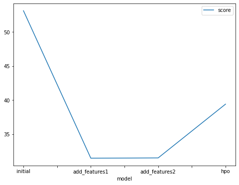

```python
# Taking the top model score from each training run and creating a line plot to show improvement
# You can create these in the notebook and save them to PNG or use some other tool (e.g. google sheets, excel)
fig = pd.DataFrame(
    {
        "model": ["initial", "add_features1", "add_features2", "hpo"],
        "score": [53.10, 31.49, 31.53, 39.41]
    }
).plot(x="model", y="score", figsize=(8, 6)).get_figure()
fig.savefig('./img/model_train_score.png')
```

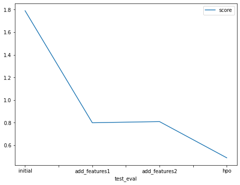

```python
# Take the 3 kaggle scores and creating a line plot to show improvement: note that Kaggle score is RMSLE rather than RMSE
fig = pd.DataFrame(
    {
        "test_eval": ["initial", "add_features1", "add_features2", "hpo"],
        "score": [1.79, 0.80, 0.81, 0.49]
    }
).plot(x="test_eval", y="score", figsize=(8, 6)).get_figure()
fig.savefig('./img/model_test_score.png')
```

### Hyperparameter table

```python
# The 3 hyperparameters we tuned with the kaggle score as the result: note that Kaggle score is RMSLE rather than RMSE
pd.DataFrame({
    "model": ["initial", "add_features1", "add_features2", "hpo"],
    "hpo1": ['default', 'default', 'default', 'NN_TORCH: num_epochs, learning_rate, dropout_prob'],
    "hpo2": ['default', 'default', 'default', 'GBM: num_boost_rounds, n_estimators'],
    "hpo3": ['default', 'default', 'default', 'XGB: num_boost_rounds, n_estimators'],
    "score": [1.79, 0.80, 0.81, 0.49]
})
```

|  | model | hpo1 | hpo2 | hpo3 | score |
| --- | --- | --- | --- | --- | --- |
| 0 | initial | default | default | default | 1.79 |
| 1 | add_features1 | default | default | default | 0.80 |
| 2 | add_features2 | default | default | default | 0.81 |
| 3 | hpo | NN_TORCH: num_epochs, learning_rate, dropout_prob | GBM: num_boost_rounds, n_estimators | XGB: num_boost_rounds, n_estimators | 0.49 |